# Internet Privacy Poll

##### *Unit-1: Introduction to Analytics*

Internet privacy has gained widespread attention in recent years. To measure the degree to which people are concerned about hot-button issues like Internet privacy, social scientists conduct polls in which they interview a large number of people about the topic. In this assignment, we will analyze data from a July 2013 Pew Internet and American Life Project poll on Internet anonymity and privacy, which involved interviews across the United States. While the full polling data can be found [here](http://bit.ly/2pmP5DZ), we will use a more limited version of the results, available in AnonymityPoll.csv.

The dataset has the following fields (all Internet use-related fields were only collected from interviewees who either use the Internet or have a smartphone):

- `Internet.Use`: A binary variable indicating if the interviewee uses the Internet, at least occasionally (equals 1 if the interviewee uses the Internet, and equals 0 if the interviewee does not use the Internet).
- `Smartphone`: A binary variable indicating if the interviewee has a smartphone (equals 1 if they do have a smartphone, and equals 0 if they don’t have a smartphone).
- `Sex`: Male or Female.
- `Age`: Age in years.
- `State`: State of residence of the interviewee.
- `Region`: Census region of the interviewee (Midwest, Northeast, South, or West).
- `Conservativeness`: Self-described level of conservativeness of interviewee, from 1 (very liberal) to 5 (very conservative).
- `Info.On.Internet`: Number of the following items this interviewee believes to be available on the Internet for others to see: [1] Their email address; [2] Their home address; [3] Their home phone number; [4] Their cell phone number; [5] The employer/company they work for; [6] Their political party or political affiliation; [7] Things they’ve written that have their name on it; [8] A photo of them; [9] A video of them; [10] Which groups or organizations they belong to; [11] Their birth date.
- `Worry.About.Info`: A binary variable indicating if the interviewee worries about how much information is available about them on the Internet (equals 1 if they worry, and equals 0 if they don’t worry).
- `Privacy.Importance`: A score from 0 (privacy is not too important) to 100 (privacy is very important), which combines the degree to which they find privacy important in the following: [1] The websites they browse; [2] Knowledge of the place they are located when they use the Internet; [3] The content and files they download; [4] The times of day they are online; [5] The applications or programs they use; [6] The searches they perform; [7] The content of their email; [8] The people they exchange email with; [9] The content of their online chats or hangouts with others.
- `Anonymity.Possible`: A binary variable indicating if the interviewee thinks it’s possible to use the Internet anonymously, meaning in such a way that online activities can’t be traced back to them (equals 1 if he/she believes you can, and equals 0 if he/she believes you can’t).
- `Tried.Masking.Identity`: A binary variable indicating if the interviewee has ever tried to mask his/her identity when using the Internet (equals 1 if he/she has tried to mask his/her identity, and equals 0 if he/she has not tried to mask his/her identity).
- `Privacy.Laws.Effective`: A binary variable indicating if the interviewee believes United States law provides reasonable privacy protection for Internet users (equals 1 if he/she believes it does, and equals 0 if he/she believes it doesn’t).

#### Loading and Summarizing the Dataset

Using read.csv(), load the dataset from AnonymityPoll.csv into a data frame called ‘poll’ and summarize it with the `summary()` and `str()`.

##### 1.1 How many people participated in the poll?

```r
poll = read.csv("AnonymityPoll.csv")
str(poll)
```

```
## 'data.frame':    1002 obs. of  13 variables:
##  $ Internet.Use          : int  1 1 0 1 0 1 1 0 0 1 ...
##  $ Smartphone            : int  0 0 1 0 NA 1 0 0 NA 0 ...
##  $ Sex                   : Factor w/ 2 levels "Female","Male": 2 2 1 2 1 2 1 1 2 1 ...
##  $ Age                   : int  62 45 70 70 80 49 52 76 75 76 ...
##  $ State                 : Factor w/ 49 levels "Alabama","Arizona",..: 20 39 29 10 10 41 21 31 32 32 ...
##  $ Region                : Factor w/ 4 levels "Midwest","Northeast",..: 2 3 2 3 3 3 1 2 3 3 ...
##  $ Conservativeness      : int  4 1 4 4 4 4 3 3 4 4 ...
##  $ Info.On.Internet      : int  0 1 0 3 NA 6 3 NA NA 0 ...
##  $ Worry.About.Info      : int  1 0 0 1 NA 0 1 NA NA 0 ...
##  $ Privacy.Importance    : num  100 0 NA 88.9 NA ...
##  $ Anonymity.Possible    : int  0 1 0 1 NA 1 0 NA NA 1 ...
##  $ Tried.Masking.Identity: int  0 0 0 0 NA 1 0 NA NA 0 ...
##  $ Privacy.Laws.Effective: int  0 1 NA 0 NA 0 1 NA 0 1 ...
```

```r
summary(poll)
```

```
##   Internet.Use      Smartphone         Sex           Age
##  Min.   :0.0000   Min.   :0.0000   Female:505   Min.   :18.00
##  1st Qu.:1.0000   1st Qu.:0.0000   Male  :497   1st Qu.:37.00
##  Median :1.0000   Median :1.0000                Median :55.00
##  Mean   :0.7742   Mean   :0.5078                Mean   :52.37
##  3rd Qu.:1.0000   3rd Qu.:1.0000                3rd Qu.:66.00
##  Max.   :1.0000   Max.   :1.0000                Max.   :96.00
##  NA's   :1        NA's   :43                    NA's   :27
##           State           Region    Conservativeness Info.On.Internet
##  California  :103   Midwest  :239   Min.   :1.000    Min.   : 0.000
##  Texas       : 72   Northeast:166   1st Qu.:3.000    1st Qu.: 2.000
##  New York    : 60   South    :359   Median :3.000    Median : 4.000
##  Pennsylvania: 45   West     :238   Mean   :3.277    Mean   : 3.795
##  Florida     : 42                   3rd Qu.:4.000    3rd Qu.: 6.000
##  Ohio        : 38                   Max.   :5.000    Max.   :11.000
##  (Other)     :642                   NA's   :62       NA's   :210
##  Worry.About.Info Privacy.Importance Anonymity.Possible
##  Min.   :0.0000   Min.   :  0.00     Min.   :0.0000
##  1st Qu.:0.0000   1st Qu.: 41.43     1st Qu.:0.0000
##  Median :0.0000   Median : 68.75     Median :0.0000
##  Mean   :0.4886   Mean   : 62.85     Mean   :0.3692
##  3rd Qu.:1.0000   3rd Qu.: 88.89     3rd Qu.:1.0000
##  Max.   :1.0000   Max.   :100.00     Max.   :1.0000
##  NA's   :212      NA's   :215        NA's   :249
##  Tried.Masking.Identity Privacy.Laws.Effective
##  Min.   :0.0000         Min.   :0.0000
##  1st Qu.:0.0000         1st Qu.:0.0000
##  Median :0.0000         Median :0.0000
##  Mean   :0.1633         Mean   :0.2617
##  3rd Qu.:0.0000         3rd Qu.:1.0000
##  Max.   :1.0000         Max.   :1.0000
##  NA's   :218            NA's   :108
```

##### 1.2 Breakdown of the number of people with smartphones.

```r
table(poll$Smartphone)
```

```
##
##   0   1
## 472 487
```

```r
summary(poll$Smartphone)
```

```
##    Min. 1st Qu.  Median    Mean 3rd Qu.    Max.    NA's
##  0.0000  0.0000  1.0000  0.5078  1.0000  1.0000      43
```

**How many interviewees responded that they use a smartphone?** 487

**How many interviewees responded that they don’t use a smartphone?** 472

**How many interviewees did not respond to the question, resulting in a missing value?** 43

##### 1.3 Use the table() function to answer the following questions:

By using the `table()` function on two variables, we can tell how they are related. To use the `table()` function on two variables, just put the two variable names inside the parentheses, separated by a comma. In the output, the possible values of the first variable will be listed in the left, and the possible values of the second variable will be listed on the top. Each entry of the table counts the number of observations in the data set that have the value of the first value in that row, and the value of the second variable in that column. For example, suppose we want to create a table of the variables “Sex” and “Region”. We would type

```r
table(poll$Sex, poll$Region)
```

```
##
##          Midwest Northeast South West
##   Female     123        90   176  116
##   Male       116        76   183  122
```

This table tells us that we have 123 people in our dataset who are female and from the Midwest, 116 people in our dataset who are male and from the Midwest, 90 people in our dataset who are female and from the Northeast, etc.

**Which of the following are states in the Midwest census region?**

```r
MidwestInterviewees = subset(poll, Region=="Midwest")
table(MidwestInterviewees$State)
```

```
##
##              Alabama              Arizona             Arkansas
##                    0                    0                    0
##           California             Colorado          Connecticut
##                    0                    0                    0
##             Delaware District of Columbia              Florida
##                    0                    0                    0
##              Georgia                Idaho             Illinois
##                    0                    0                   32
##              Indiana                 Iowa               Kansas
##                   27                   14                   14
##             Kentucky            Louisiana                Maine
##                    0                    0                    0
##             Maryland        Massachusetts             Michigan
##                    0                    0                   31
##            Minnesota          Mississippi             Missouri
##                   15                    0                   26
##              Montana             Nebraska               Nevada
##                    0                   11                    0
##        New Hampshire           New Jersey           New Mexico
##                    0                    0                    0
##             New York       North Carolina         North Dakota
##                    0                    0                    5
##                 Ohio             Oklahoma               Oregon
##                   38                    0                    0
##         Pennsylvania         Rhode Island       South Carolina
##                    0                    0                    0
##         South Dakota            Tennessee                Texas
##                    3                    0                    0
##                 Utah              Vermont             Virginia
##                    0                    0                    0
##           Washington        West Virginia            Wisconsin
##                    0                    0                   23
##              Wyoming
##                    0
```

**Which was the state in the South census region with the largest number of interviewees?**

```r
SouthInterviewees = subset(poll, Region=="South")
table(SouthInterviewees$State)
```

```
##
##              Alabama              Arizona             Arkansas
##                   11                    0                   10
##           California             Colorado          Connecticut
##                    0                    0                    0
##             Delaware District of Columbia              Florida
##                    6                    2                   42
##              Georgia                Idaho             Illinois
##                   34                    0                    0
##              Indiana                 Iowa               Kansas
##                    0                    0                    0
##             Kentucky            Louisiana                Maine
##                   25                   17                    0
##             Maryland        Massachusetts             Michigan
##                   18                    0                    0
##            Minnesota          Mississippi             Missouri
##                    0                   11                    0
##              Montana             Nebraska               Nevada
##                    0                    0                    0
##        New Hampshire           New Jersey           New Mexico
##                    0                    0                    0
##             New York       North Carolina         North Dakota
##                    0                   32                    0
##                 Ohio             Oklahoma               Oregon
##                    0                   14                    0
##         Pennsylvania         Rhode Island       South Carolina
##                    0                    0                   12
##         South Dakota            Tennessee                Texas
##                    0                   17                   72
##                 Utah              Vermont             Virginia
##                    0                    0                   31
##           Washington        West Virginia            Wisconsin
##                    0                    5                    0
##              Wyoming
##                    0
```

#### Internet and Smartphone Users

As mentioned in the introduction to this problem, many of the response variables (`Info.On.Internet`, `Worry.About.Info`, `Privacy.Importance`, `Anonymity.Possible`, and `Tried.Masking.Identity`) were not collected if an interviewee does not use the Internet or a smartphone, meaning the variables will have missing values for these interviewees.

##### 2.1 Answer the following questions about the distribution of users.

**How many interviewees reported not having used the Internet and not having used a smartphone?**

```r
table(poll$Internet.Use, poll$Smartphone)
```

```
##
##       0   1
##   0 186  17
##   1 285 470
```

186

**How many interviewees reported having used the Internet and having used a smartphone?** 470

**How many interviewees reported having used the Internet but not having used a smartphone?** 285

**How many interviewees reported having used a smartphone but not having used the Internet?** 17

##### 2.2 How many missing values?

```r
summary(poll)
```

```
##   Internet.Use      Smartphone         Sex           Age
##  Min.   :0.0000   Min.   :0.0000   Female:505   Min.   :18.00
##  1st Qu.:1.0000   1st Qu.:0.0000   Male  :497   1st Qu.:37.00
##  Median :1.0000   Median :1.0000                Median :55.00
##  Mean   :0.7742   Mean   :0.5078                Mean   :52.37
##  3rd Qu.:1.0000   3rd Qu.:1.0000                3rd Qu.:66.00
##  Max.   :1.0000   Max.   :1.0000                Max.   :96.00
##  NA's   :1        NA's   :43                    NA's   :27
##           State           Region    Conservativeness Info.On.Internet
##  California  :103   Midwest  :239   Min.   :1.000    Min.   : 0.000
##  Texas       : 72   Northeast:166   1st Qu.:3.000    1st Qu.: 2.000
##  New York    : 60   South    :359   Median :3.000    Median : 4.000
##  Pennsylvania: 45   West     :238   Mean   :3.277    Mean   : 3.795
##  Florida     : 42                   3rd Qu.:4.000    3rd Qu.: 6.000
##  Ohio        : 38                   Max.   :5.000    Max.   :11.000
##  (Other)     :642                   NA's   :62       NA's   :210
##  Worry.About.Info Privacy.Importance Anonymity.Possible
##  Min.   :0.0000   Min.   :  0.00     Min.   :0.0000
##  1st Qu.:0.0000   1st Qu.: 41.43     1st Qu.:0.0000
##  Median :0.0000   Median : 68.75     Median :0.0000
##  Mean   :0.4886   Mean   : 62.85     Mean   :0.3692
##  3rd Qu.:1.0000   3rd Qu.: 88.89     3rd Qu.:1.0000
##  Max.   :1.0000   Max.   :100.00     Max.   :1.0000
##  NA's   :212      NA's   :215        NA's   :249
##  Tried.Masking.Identity Privacy.Laws.Effective
##  Min.   :0.0000         Min.   :0.0000
##  1st Qu.:0.0000         1st Qu.:0.0000
##  Median :0.0000         Median :0.0000
##  Mean   :0.1633         Mean   :0.2617
##  3rd Qu.:0.0000         3rd Qu.:1.0000
##  Max.   :1.0000         Max.   :1.0000
##  NA's   :218            NA's   :108
```

**How many interviewees have a missing value for their Internet use?** 1

**How many interviewees have a missing value for their smartphone use?** 43

##### 2.3 Subsetting the Data

Use the subset function to obtain a data frame called “limited”, which is limited to interviewees who reported Internet use or who reported smartphone use. In lecture, we used the & symbol to use two criteria to make a subset of the data. To only take observations that have a certain value in one variable or the other, the | character can be used in place of the & symbol. This is also called a logical “or” operation.

**How many interviewees are in the new data frame?**

```r
limited = subset(poll, Internet.Use==1 | Smartphone==1)
nrow(limited)
```

```
## [1] 792
```

#### Summarizing Opinions About Internet Privacy

##### 3.1 Which variables have missing values in the limited data frame?

```r
summary(limited)
```

```
##   Internet.Use      Smartphone         Sex           Age
##  Min.   :0.0000   Min.   :0.0000   Female:392   Min.   :18.00
##  1st Qu.:1.0000   1st Qu.:0.0000   Male  :400   1st Qu.:33.00
##  Median :1.0000   Median :1.0000                Median :51.00
##  Mean   :0.9785   Mean   :0.6308                Mean   :48.57
##  3rd Qu.:1.0000   3rd Qu.:1.0000                3rd Qu.:62.00
##  Max.   :1.0000   Max.   :1.0000                Max.   :93.00
##                   NA's   :20                    NA's   :22
##             State           Region    Conservativeness Info.On.Internet
##  California    : 89   Midwest  :172   Min.   :1.000    Min.   : 0.000
##  Texas         : 57   Northeast:128   1st Qu.:3.000    1st Qu.: 2.000
##  New York      : 45   South    :288   Median :3.000    Median : 4.000
##  Pennsylvania  : 33   West     :204   Mean   :3.237    Mean   : 3.795
##  Florida       : 32                   3rd Qu.:4.000    3rd Qu.: 6.000
##  North Carolina: 28                   Max.   :5.000    Max.   :11.000
##  (Other)       :508                   NA's   :45
##  Worry.About.Info Privacy.Importance Anonymity.Possible
##  Min.   :0.0000   Min.   :  0.00     Min.   :0.0000
##  1st Qu.:0.0000   1st Qu.: 41.43     1st Qu.:0.0000
##  Median :0.0000   Median : 68.75     Median :0.0000
##  Mean   :0.4886   Mean   : 62.85     Mean   :0.3692
##  3rd Qu.:1.0000   3rd Qu.: 88.89     3rd Qu.:1.0000
##  Max.   :1.0000   Max.   :100.00     Max.   :1.0000
##  NA's   :2        NA's   :5          NA's   :39
##  Tried.Masking.Identity Privacy.Laws.Effective
##  Min.   :0.0000         Min.   :0.0000
##  1st Qu.:0.0000         1st Qu.:0.0000
##  Median :0.0000         Median :0.0000
##  Mean   :0.1633         Mean   :0.2559
##  3rd Qu.:0.0000         3rd Qu.:1.0000
##  Max.   :1.0000         Max.   :1.0000
##  NA's   :8              NA's   :65
```

##### 3.2 What is the average number of pieces of personal information on the Internet?

```r
mean(limited$Info.On.Internet)
```

```
## [1] 3.795455
```

##### 3.3 - Summary of Info.On.Internet

**How many interviewees reported a value of 0 for Info.On.Internet?**

```r
table(limited$Info.On.Internet)
```

```
##
##   0   1   2   3   4   5   6   7   8   9  10  11
## 105  84  95 101 104  94  67  63  40  18  13   8
```

105

**How many interviewees reported the maximum value of 11 for Info.On.Internet?** 8

##### 3.4 What proportion of interviewees who answered the Worry.About.Info question worry about how much information is available about them on the Internet?

Note that to compute this proportion you will be dividing by the number of people who answered the Worry.About.Info question, not the total number of people in the data frame.

```r
sum(limited$Worry.About.Info==1, na.rm=T)/nrow(limited - 2)
```

```
## [1] 0.4873737
```

```r
# 2 is the number of NAs in this column
```

##### 3.5 What proportion of interviewees who answered the Anonymity.Possible question think it is possible to be completely anonymous on the Internet?

```r
sum(limited$Anonymity.Possible==1, na.rm=T)/(nrow(limited) - 39)
```

```
## [1] 0.3691899
```

##### 3.6 What proportion of interviewees who answered the Tried.Masking.Identity question have tried masking their identity on the Internet?

```r
sum(limited$Tried.Masking.Identity==1, na.rm=T)/(nrow(limited) - 8)
```

```
## [1] 0.1632653
```

##### 3.7 What proportion of interviewees who answered the Privacy.Laws.Effective question find the United States privacy laws effective?

```r
sum(limited$Privacy.Laws.Effective==1, na.rm=T)/(nrow(limited) - 65)
```

```
## [1] 0.2558459
```

#### Relating Demographics to Polling Results

Often, we are interested in whether certain characteristics of interviewees (e.g., their age or political opinions) affect their opinions on the topic of the poll (in this case, opinions on privacy). In this section, we will investigate the relationship between the characteristics Age and Smartphone and outcome variables Info.On.Internet and Tried.Masking.Identity, again using the limited data frame we built in an earlier section of this problem.

##### 4.1 Build a histogram of the age of interviewees. What is the best-represented age group in the population?

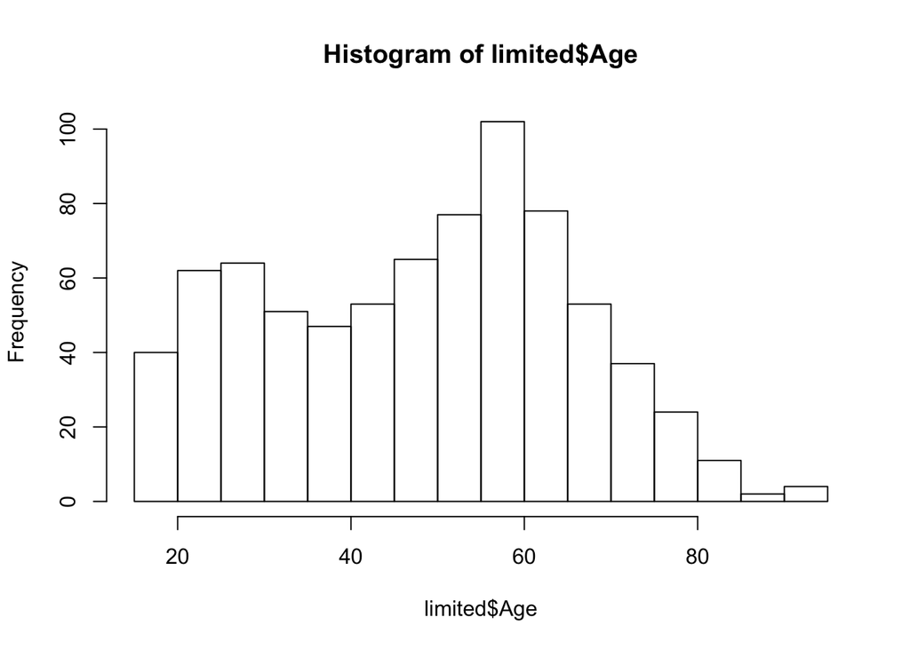

```r
hist(limited$Age)
```

People aged about 60 years old.

##### 4.2 What is the largest number of interviewees that have exactly the same value in Age & Info.On.Internet variable?

Both Age and Info.On.Internet are variables that take on many values, so a good way to observe their relationship is through a graph. We learned in lecture that we can plot Age against Info.On.Internet with the command `plot(limited$Age, limited$Info.On.Internet)`. However, because Info.On.Internet takes on a small number of values, multiple points can be plotted in exactly the same location on this graph.

In other words, what is the largest number of overlapping points in the plot `plot(limited$Age, limited$Info.On.Internet)?`

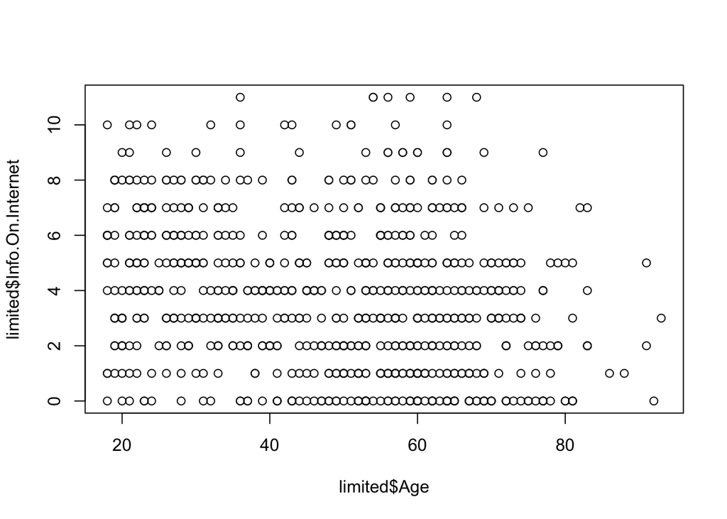

```r
max(table(limited$Age, limited$Info.On.Internet))
```

```
## [1] 6
```

##### 4.3 What appears to be the functionality of the jitter command based on the following information?

To avoid points covering each other up, we can use the jitter() function on the values we pass to the plot function. Experimenting with the command `jitter(c(1, 2, 3))`, what appears to be the functionality of the jitter command?

`jitter` adds or subtracts a small amount of random noise to the values passed to it, and two runs will yield different results.

##### 4.4 Based on the plot, what relationship is observed between Age and Info.On.Internet?

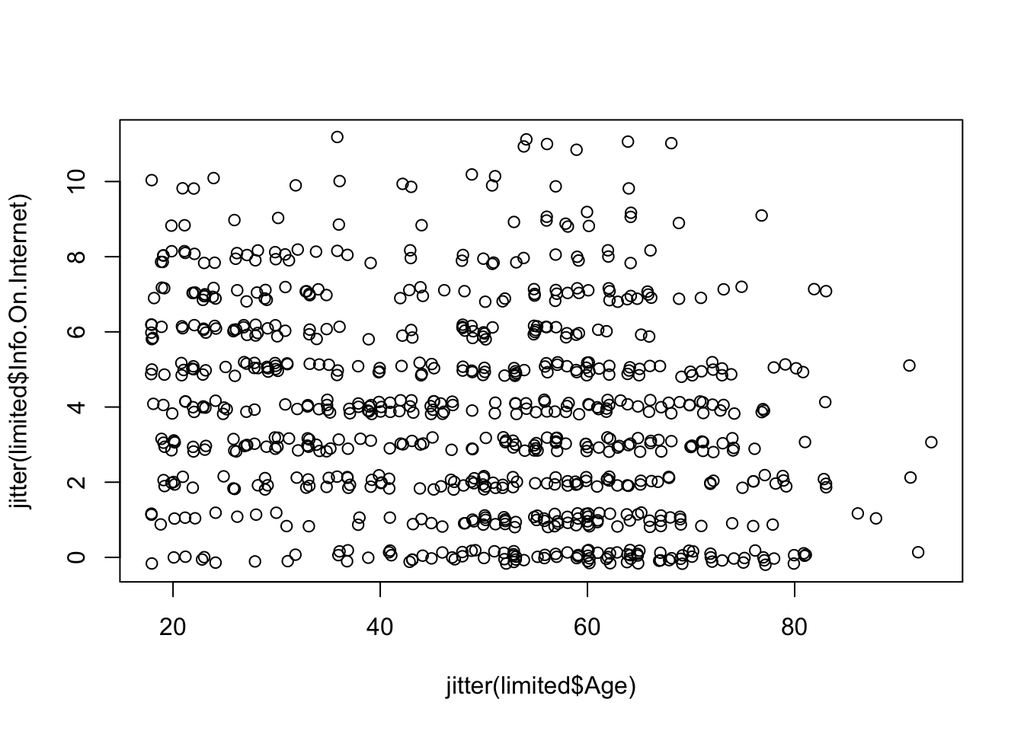

```r
plot(jitter(limited$Age), jitter(limited$Info.On.Internet))
```

Older age seems moderately associated with a small value for Info.On.Internet. For younger people aged 18-30, the average value of Info.On.Internet appears to be roughly 5, while most people aged 60 and older have value less than 5.

##### 4.5 Using tapply() to obtain the summary of Info.On.Internet() broken down by smartphone user.

**What is the average Info.On.Internet value for smartphone users?**

```r
tapply(limited$Info.On.Internet, limited$Smartphone, summary)
```

```
## $`0`
##    Min. 1st Qu.  Median    Mean 3rd Qu.    Max.
##   0.000   1.000   3.000   2.923   5.000  11.000
##
## $`1`
##    Min. 1st Qu.  Median    Mean 3rd Qu.    Max.
##   0.000   2.000   4.000   4.368   6.000  11.000
```

4.368

**What is the average Info.On.Internet value for non-smartphone users?** 2.923

##### 4.6 Using tapply() to break down Tried.Masking.Identity variable for smartphone/non-smartphone users.

**What proportion of smartphone users who answered the Tried.Masking.Identity** **question have tried masking their identity when using the Internet?**

```r
tapply(limited$Tried.Masking.Identity, limited$Smartphone, table)
```

```
## $`0`
##
##   0   1
## 248  33
##
## $`1`
##
##   0   1
## 390  93
```

Among smartphone users, 93 tried masking their identity and 390 did not, resulting in proportion 93/(93+390)=0.1925.

**What proportion of non-smartphone users who answered the** **Tried.Masking.Identity question have tried masking their identity when** **using the Internet?**

```r
tapply(limited$Tried.Masking.Identity, limited$Smartphone, mean, na.rm=T)
```

```
##         0         1
## 0.1174377 0.1925466
```

Next week, we will begin to more formally characterize how an outcome variable like Info.On.Internet can be predicted with a variable like Age or Smartphone.

*End of Homework Assignment*